# BAN614 Winter 2023: Final Project

## The training model that had all the variables as predictors

```r
summary(LogisticModel.train)
```

```
Call:
glm(formula = Status ~ ., family = binomial, data = df.train)

Deviance Residuals:
    Min       1Q   Median       3Q      Max
-1.9039  -0.6901  -0.2811   0.7485   3.4346

Coefficients: (7 not defined because of singularities)
                                        Estimate  Std. Error z value             Pr(>|z|)
(Intercept)                           1.00335563  0.90802383   1.105               0.2692
GenderMale                           -0.02311803  0.07230618  -0.320               0.7492
SeniorCitizen1                        0.18484835  0.09340678   1.979               0.0478 *
PartnerYes                           -0.04562400  0.08627929  -0.529               0.5969
DependentsYes                        -0.18293351  0.09974554  -1.834               0.0667 .
Tenure                               -0.06291879  0.00696366  -9.035 < 0.0000000000000002 ***
PhoneServiceYes                      -0.11828856  0.72247739  -0.164               0.8699
MultipleLinesNo phone service                 NA          NA      NA                   NA
MultipleLinesYes                      0.38352683  0.19727625   1.944               0.0519 .
InternetServiceFiber optic            1.41440918  0.88740175   1.594               0.1110
InternetServiceNo                    -1.46542424  0.89929328  -1.630               0.1032
OnlineSecurityNo internet service             NA          NA      NA                   NA
OnlineSecurityYes                    -0.32582845  0.19876740  -1.639               0.1012
OnlineBackupNo internet service               NA          NA      NA                   NA
OnlineBackupYes                      -0.04926823  0.19555449  -0.252               0.8011
DeviceProtectionNo internet service           NA          NA      NA                   NA
DeviceProtectionYes                   0.09890139  0.19781275   0.500               0.6171
TechSupportNo internet service                NA          NA      NA                   NA
TechSupportYes                       -0.22605001  0.20083454  -1.126               0.2604
StreamingTVNo internet service                NA          NA      NA                   NA
StreamingTVYes                        0.41111343  0.36278260   1.133               0.2571
StreamingMoviesNo internet service            NA          NA      NA                   NA
StreamingMoviesYes                    0.45653503  0.36385236   1.255               0.2096
ContractOne year                     -0.61020562  0.11995179  -5.087     0.00000036359842 ***
ContractTwo year                     -1.33257698  0.19453255  -6.850     0.00000000000738 ***
PaperlessBillingYes                   0.34891526  0.08303345   4.202     0.00002644444500 ***
PaymentMethodCredit card (automatic) -0.23178617  0.12792622  -1.812               0.0700 .
PaymentMethodElectronic check         0.26695748  0.10468556   2.550               0.0108 *
PaymentMethodMailed check            -0.11362624  0.12854406  -0.884               0.3767
MonthlyCharges                       -0.02770871  0.03535688  -0.784               0.4332
TotalCharges                          0.00036606  0.00007892   4.638     0.00000351571815 ***
---
Signif. codes:  0 '***' 0.001 '**' 0.01 '*' 0.05 '.' 0.1 ' ' 1

(Dispersion parameter for binomial family taken to be 1)

    Null deviance: 6528.5  on 5599  degrees of freedom
Residual deviance: 4670.8  on 5576  degrees of freedom
AIC: 4718.8

Number of Fisher Scoring iterations: 6
```

*OBSERVATION;* The performance of our logistic regression is evaluated with specific key metrics;

```r
# Create a vector of prediction classes based on the value of the prediction probability
Prediction_Classes_0.3 <- ifelse(Predictions_Probabilities_2 > 0.3, "Current", "Left")

# Use the table function and use the prediction classes and the actual classes as the inputs
table(Prediction_Classes_0.3, df.test$Status)
```

```
Prediction_Classes_0.3 Current Left
               Current     232  267
               Left        821   79
```

### Accuracy(%)

```r
accuracy.glm.0.3 <- (232+ 79)/(232 +267+821+79)*100
accuracy.glm.0.3
```

```
[1] 22.23016
```

## Thresholds is 0.6

```r
# Create a vector of prediction classes based on the value of the prediction probability
Prediction_Classes_0.6 <- ifelse(Predictions_Probabilities_2> 0.6, "Current", "Left")

# Use the table function and use the prediction classes and the actual classes as the inputs
table(Prediction_Classes_0.6, df.test$Status)
```

```
Prediction_Classes_0.6 Current Left
               Current      67  141
               Left        986  205
```

### Accuracy(%)

```r
accuracy.glm.0.6 <- (67+205)/(67+141+986+205)*100
accuracy.glm.0.6
```

```
[1] 19.44246
```

## Thresholds is 0.9

```r
# Create a vector of prediction classes based on the value of the prediction probability
Prediction_Classes_0.9 <- ifelse(Predictions_Probabilities_2 > 0.9, "Current", "Left")

# Use the table function and use the prediction classes and the actual classes as the inputs
table(Prediction_Classes_0.9, df.test$Status)
```

```
Prediction_Classes_0.9 Current Left
                  Left    1053  346
```

### Accuracy(%)

```r
accuracy.glm.0.9 <- 0/(1053+346)*100
accuracy.glm.0.9
```

```
[1] 0
```

3. Naive Bayes
- Use the training set to build a Naive Bayes model to predict the probability for losing a customer.

## Create the Naive Bayes Classifier

```r
# Store the Naive Bayes Classifier model in NaiveBayes.train
NaiveBayes.train <- naiveBayes(Status ~ Gender + SeniorCitizen + Partner + Dependents + Tenure + PhoneService + MultipleLines + InternetService + OnlineSecurity + OnlineBackup + DeviceProtection + TechSupport + StreamingTV + StreamingMovies + Contract + PaperlessBilling + PaymentMethod + MonthlyCharges + TotalCharges
,df.train,laplace = 0.01)

# Create the summary of the Logistic Regression Model
summary(NaiveBayes.train)
```

```
          Length Class  Mode
apriori    2     table  numeric
tables    19     -none- list
levels     2     -none- character
isnumeric 19     -none- logical
call       4     -none- call
```

## Making predictions

```r
Predictions <- predict(NaiveBayes.train,newdata = df.test)
```

## Obtain the posterior probabilities and then assign the class based on the cutoff we want(0.5)

```r
predictions.test.prob <- predict(NaiveBayes.train, newdata = df.test, type = "raw")
head(predictions.test.prob)
```

```
         Current      Left
[1,] 0.052281434 0.9477186
[2,] 0.886616657 0.1133833
[3,] 0.147833190 0.8521668
[4,] 0.001049909 0.9989501
[5,] 0.364197141 0.6358029
[6,] 0.008429241 0.9915708
```

### Threshold of 0.5

```r
# Extract the second column of the array and store
predictions.test.Left.prob <- predictions.test.prob[,2]
# Now you can set your own cutoff and assign the class. Here I am using 0.4
predictions.test.class0.5 <- ifelse(predictions.test.Left.prob > 0.5, "Left", "Current")
```

## Create the confusion matrix

```r
table(predictions.test.class0.5, df.test$Status)
```

```
predictions.test.class0.5 Current Left
                  Current     746   70
                  Left        307  276
```

## Accuracy(%)

```r
accuracy.nb.0.5 <- (746 + 276)/(746 + 70 + 307 + 276) * 100
accuracy.nb.0.5
```

```
[1] 73.05218
```

## Plotting ROc

```r
# suppress the warnings by setting warn=-1
options(warn=-1)


# We can do it by accessing the list object *Default_pred*. We first use the name *posterior* within double braces to access the matrix and then refer to the second column of the matrix using the square brackets.

Probability_Left <- predictions.test.Left.prob

# * We then save it as a dataframe and then also add the actual default values from the original dataset.

Default_thresholds <- data.frame(Probability_Left)
Default_thresholds$Actual_defaults <- df.test$Status

# We now add another column and assign classes based on the threshold of 50%. If the posterior is > 0.5 then we assign a "Left" , else "Current".

Default_thresholds <- Default_thresholds %>%
  mutate(Class_th_0.5 = ifelse(Probability_Left > 0.5, "Left", "Current"), Class_th_0.5 = factor(Class_th_0.5, levels=c("Current","Left")))

str(Default_thresholds)
```

```
'data.frame':   1399 obs. of  3 variables:
 $ Probability_Left: num  0.948 0.113 0.852 0.999 0.636 ...
 $ Actual_defaults : Factor w/ 2 levels "Current","Left": 1 1 2 2 1 2 2 1 1 1 ...
 $ Class_th_0.5    : Factor w/ 2 levels "Current","Left": 2 1 2 2 2 2 2 2 2 2 ...
```

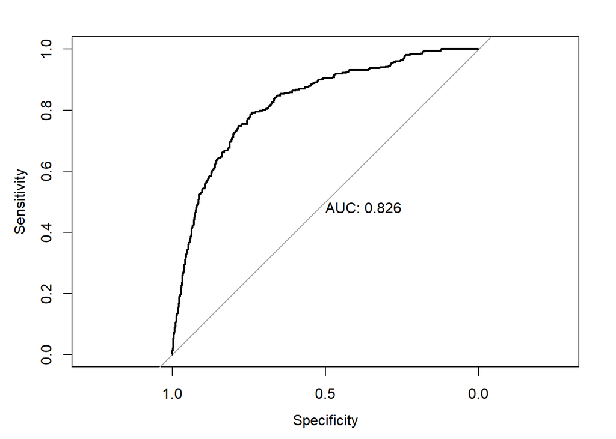

```
Call:
roc.default(response = Default_thresholds$Actual_defaults, predictor = Default_thresholds$Probability_Left,     plot = TRUE, print.auc = TRUE)

Data: Default_thresholds$Probability_Left in 1053 controls (Default_thresholds$Actual_defaults Current) < 346 cases (Default_thresholds$Actual_defaults Left).
Area under the curve: 0.826
```

```r
## Ploting the ROC
roc(Default_thresholds$Actual_defaults,Default_thresholds$Probability_Left,plot=TRUE,print.auc=TRUE)
```

- Try different combinations of variables and arrive at the model that maximizes AUC (Area Under the Curve) for the ROC plots.

## Model with these as predictor variable;

## Gender , SeniorCitizen , Partner , Dependents , Tenure , PhoneService , MultipleLines , InternetService , OnlineSecurity , OnlineBackup , DeviceProtection , TechSupport , StreamingTV , StreamingMovies , Contract , PaperlessBilling , PaymentMethod

```r
# Create the Naive Bayes Classifier
# Store the Naive Bayes Classifier model in NaiveBayes.train_2
NaiveBayes.train_2 <- naiveBayes(Status ~ Gender + SeniorCitizen + Partner + Dependents + Tenure + PhoneService + MultipleLines + InternetService + OnlineSecurity + OnlineBackup + DeviceProtection + TechSupport + StreamingTV + StreamingMovies + Contract + PaperlessBilling + PaymentMethod
,df.train,laplace = 0.01)

# Create the summary of the Logistic Regression Model
summary(NaiveBayes.train_2)
```

```
          Length Class  Mode
apriori    2     table  numeric
tables    17     -none- list
levels     2     -none- character
isnumeric 17     -none- logical
call       4     -none- call
```

```r
## Obtain the posterior probabilities and then assign the class based on the cutoff we want(0.5)

predictions.test.prob_2 <- predict(NaiveBayes.train_2, newdata = df.test, type = "raw")
head(predictions.test.prob_2)
```

```
         Current       Left
[1,] 0.035587389 0.96441261
[2,] 0.905741655 0.09425834
[3,] 0.201767702 0.79823230
[4,] 0.002157934 0.99784207
[5,] 0.419676536 0.58032346
[6,] 0.008084507 0.99191549
```

```r
# Extract the second column of the array and store
predictions.test.Left.prob_2 <- predictions.test.prob_2[,2]

# We can do it by accessing the list object *Default_pred*. We first use the name *posterior* within bouble braces to access the matrix and then refer to the second column of the matrix using the square brackets.

Probability_Left_2 <- predictions.test.Left.prob_2

# * We then save it as a dataframe and then also add the actual default values from the original dataset.

Default_thresholds_2 <- data.frame(Probability_Left_2)
Default_thresholds$Actual_defaults <- df.test$Status

# We now add another column and assign classes based on the threshold of 50%. If the posterior is > 0.5 then we assign a "Left" , else "Current".

Default_thresholds_2 <- Default_thresholds_2 %>%
  mutate(Class_th_0.5 = ifelse(Probability_Left > 0.5, "Left", "Current"), Class_th_0.5 = factor(Class_th_0.5, levels=c("Current","Left")))

str(Default_thresholds_2)
```

```
'data.frame':   1399 obs. of  2 variables:
 $ Probability_Left_2: num  0.9644 0.0943 0.7982 0.9978 0.5803 ...
 $ Class_th_0.5      : Factor w/ 2 levels "Current","Left": 2 1 2 2 2 2 2 2 2 2 ...
```

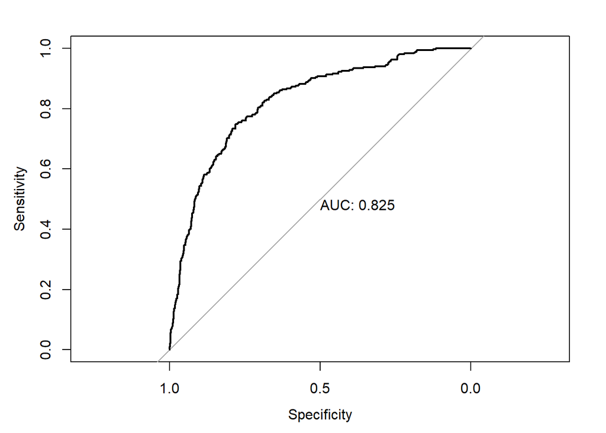

```
Call:
roc.default(response = Default_thresholds$Actual_defaults, predictor = Default_thresholds_2$Probability_Left,     plot = TRUE, print.auc = TRUE)

Data: Default_thresholds_2$Probability_Left in 1053 controls (Default_thresholds$Actual_defaults Current) < 346 cases (Default_thresholds$Actual_defaults Left).
Area under the curve: 0.8245
```

```r
## Ploting the ROC
roc(Default_thresholds$Actual_defaults,Default_thresholds_2$Probability_Left,plot=TRUE,print.auc=TRUE)
```

## Model with these as predictor variable;

## Gender , SeniorCitizen , Tenure , PhoneService , InternetService , OnlineSecurity , OnlineBackup , DeviceProtection , TechSupport , StreamingTV , StreamingMovies , Contract , PaperlessBilling , PaymentMethod , PaymentMethod , MonthlyCharges , TotalCharges

```r
# Create the Naive Bayes Classifier
# Store the Naive Bayes Classifier model in NaiveBayes.train_3
NaiveBayes.train_3 <- naiveBayes(Status ~ Gender + SeniorCitizen  + Tenure + PhoneService + InternetService + OnlineSecurity + OnlineBackup + DeviceProtection + TechSupport + StreamingTV + StreamingMovies + Contract + PaperlessBilling + PaymentMethod + PaymentMethod + MonthlyCharges + TotalCharges, df.train,laplace = 0.01)

# Create the summary of the Logistic Regression Model
summary(NaiveBayes.train_3)
```

```
          Length Class  Mode
apriori    2     table  numeric
tables    16     -none- list
levels     2     -none- character
isnumeric 16     -none- logical
call       4     -none- call
```

```r
## Obtain the posterior probabilities and then assign the class based on the cutoff we want(0.5)

predictions.test.prob_3 <- predict(NaiveBayes.train_3, newdata = df.test, type = "raw")
head(predictions.test.prob_3)
```

```
         Current       Left
[1,] 0.041249221 0.95875078
[2,] 0.928035694 0.07196431
[3,] 0.222451656 0.77754834
[4,] 0.001730281 0.99826972
[5,] 0.149129562 0.85087044
[6,] 0.013575171 0.98642483
```

```r
# Extract the second column of the array and store
predictions.test.Left.prob_3 <- predictions.test.prob_3[,2]

# We can do it by accessing the list object *Default_pred*. We first use the name *posterior* within bouble braces to access the matrix and then refer to the second column of the matrix using the square brackets.

Probability_Left_3 <- predictions.test.Left.prob_3

# * We then save it as a dataframe and then also add the actual default values from the original dataset.

Default_thresholds_3 <- data.frame(Probability_Left_3)
Default_thresholds$Actual_defaults <- df.test$Status

# We now add another column and assign classes based on the threshold of 50%. If the posterior is > 0.5 then we assign a "Left" , else "Current".

Default_thresholds_3 <- Default_thresholds_3 %>%
  mutate(Class_th_0.5 = ifelse(Probability_Left> 0.5, "Left", "Current"), Class_th_0.5 = factor(Class_th_0.5, levels=c("Current","Left")))

str(Default_thresholds_3)
```

```
'data.frame':   1399 obs. of  2 variables:
 $ Probability_Left_3: num  0.959 0.072 0.778 0.998 0.851 ...
 $ Class_th_0.5      : Factor w/ 2 levels "Current","Left": 2 1 2 2 2 2 2 2 2 2 ...
```

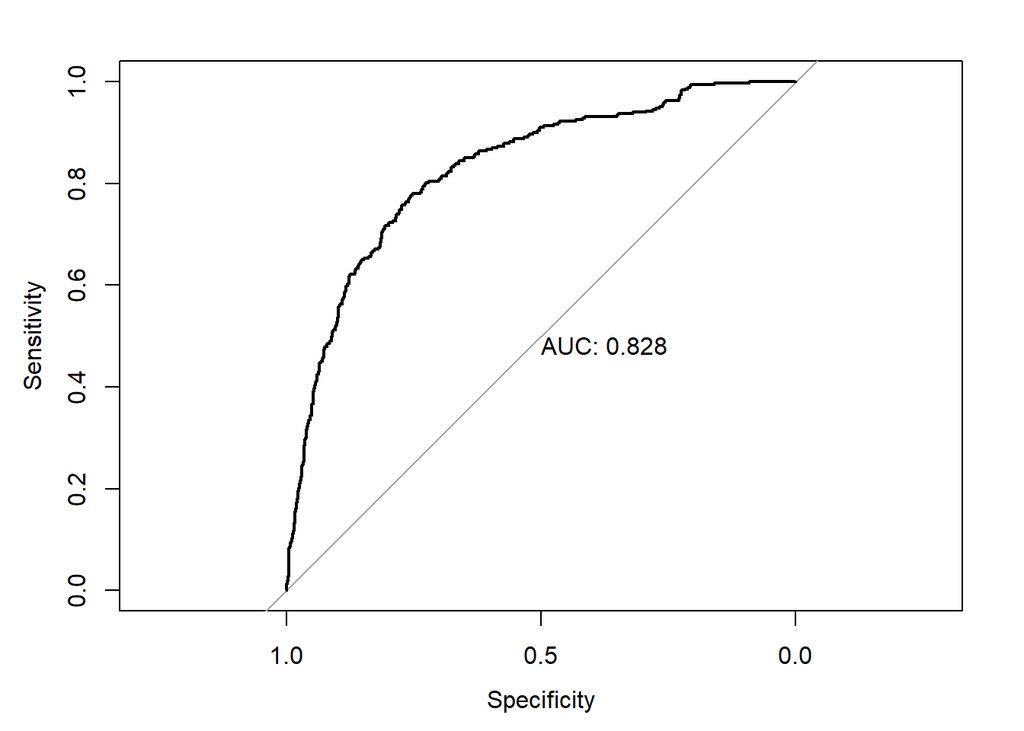

```
Call:
roc.default(response = Default_thresholds$Actual_defaults, predictor = Default_thresholds_3$Probability_Left,     plot = TRUE, print.auc = TRUE)

Data: Default_thresholds_3$Probability_Left in 1053 controls (Default_thresholds$Actual_defaults Current) < 346 cases (Default_thresholds$Actual_defaults Left).
Area under the curve: 0.8284
```

```r
## Ploting the ROC
roc(Default_thresholds$Actual_defaults,Default_thresholds_3$Probability_Left,plot=TRUE,print.auc=TRUE)
```